# Covid19_data_anaysis

2025-02-25

## COVID analysis

### 1. Introduction

COVID pandemic was a global challenge that put to the test the scientific community around the world. Although is not the first pandemic in the world, the globalization made the population to move around the globe several times a day, helping the propagation of viruses and increasing mutation of the virus, making it more problematic to fight. Is not the first time that there are curfews, quarentines and not even the first time the humanity developed a vaccine in record time. During this pandemic more tan 700 million people got infected with 7 million dead worldwide. “https://www.worldometers.info/coronavirus/” This is mortality rate of 1% (reported), bigger than Seasonal Influenza (flu) which is 0.1%, which is around 500.000 dead depending on the season. Even being a tragedy, our perception is that COVID was extremely dangerous and most infected people died, this 1% looks small. Therefore, the question arises, how deadly was the COVID-19.

### 2. Research question:

To address this question, a more formal one need to be stated in order to perform a quantitative research: “Is the infection rate, meaning, the speed of virus spread (virosity), a good estimator of death rate?”

### 3. Methodology description:

1 - Analyze the evolution of quantity of cases (trajectory) per country around the world 2 - Correlate this trajectory with the quantity of deaths per country. 3 - Data will be normalized by population 4 - Create a model to estimate the number of deaths based on number of cases.

### 4. Methodology implementation

#### Datasources

Data comes from following repository: “https://raw.githubusercontent.com/CSSEGISandData/COVID-19/master/csse_covid_19_data/csse_covid_19_time_series/”

Files are: - **Global confirmed cases** “time_series_covid19_confirmed_global.csv”

##### Convert from wide to long format

##### COMPUTE INFECTED PER MILLION

#### INSIGHTS

##### VISUALIZE VIRUS SPREAD TRAJECTORIES

[figure not shown]

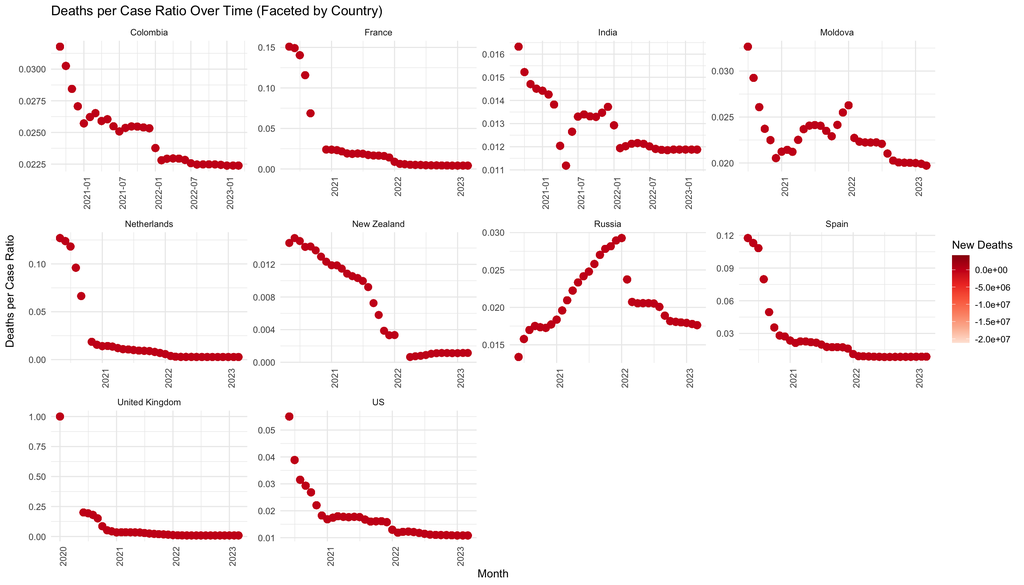

#### MODELIZATION

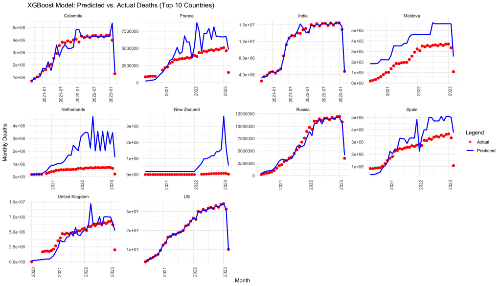

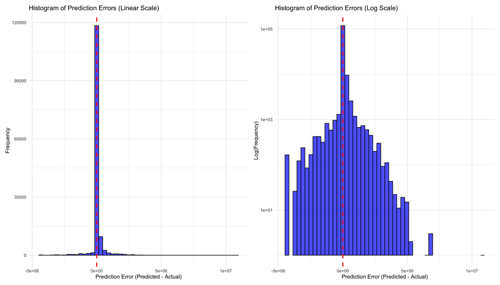

### 5. CONCLUSION

#### POSSIBLE BIAS REPORT

##### Underreporting & Inconsistent Testing

```
  - Many countries, especially in the early stages of the pandemic, had limited testing capacity, therefore, monthly cases may be underreported, which directly affects the virulence ratio calculation.
  - Death Reporting Differences: Some countries reported only confirmed COVID-19 deaths, while others included probable cases. This discrepancy can skew the new deaths/monthly cases ratio.
```

##### Population Normalization Bias

```
  - Scaling by Total Population: Normalizing infections or deaths by total country population assumes uniform exposure. This may not be true in all cases.
```

```
- Virulence Ratio Calculation. This computation assumes that all countries promptly report the cases, which may not be true for third world countries with limited resources to communicate the cases or dictatorships trying to hide their performance.
- Instability at Low Cases: When monthly cases are small, the virulence ratio (new cases/previous cases) can be highly volatile. This may cause extreme fluctuations, especially in early months.
- Artificial Capping: If the virulence ratio is arbitrarily capped at 1 (as done in some code versions), it removes important distinctions between rapidly spreading outbreaks.
```

##### Choice of Top 10 Countries

```
- If countries are selected based on total infections per million, it favors smaller nations with concentrated outbreaks (e.g., Andorra, San Marino).
- Future work: A better approach might consider infection trajectories (e.g., peak growth rate) instead of just final case counts.
```

##### Correlation Between Virulence and Deaths

```
- Deaths Lag Behind Cases: Since fatalities occur weeks after infection, directly correlating same-month virulence ratio and deaths may underestimate the relationship.
- Future work: Alternative Approach, compute lagged correlations, checking if previous months’ cases predict future deaths.
```